# **Phân tích dữ liệu lối sống nhằm hỗ trợ ra quyết định cải thiện sức khỏe**

Phân loại (Classification): "Yếu tố lối sống và sức khỏe nào (Stress Level, Sleep Duration, BMI, etc.) là quan trọng nhất trong việc dự đoán một người có bị rối loạn giấc ngủ (Sleep Disorder) hay không?"

Phân cụm (Clustering): "Liệu có thể phân chia các cá nhân thành các nhóm (Persona) với các đặc điểm lối sống và rủi ro sức khỏe khác nhau, và đặc điểm của mỗi nhóm là gì?"

## **Tổng quan**

```python
# Import thư viện
import pandas as pd
import numpy as np
import seaborn as sns
import matplotlib.pyplot as plt
import warnings
warnings.filterwarnings("ignore", category=DeprecationWarning)
```

```python
# Đọc dữ liệu
df = pd.read_csv('Sleep_health_and_lifestyle_dataset.csv')
```

```python
# Mô tả dữ liệu
df.head()
```

|  | Person ID | Gender | Age | Occupation | Sleep Duration | Quality of Sleep | Physical Activity Level | Stress Level | BMI Category | Blood Pressure | Heart Rate | Daily Steps | Sleep Disorder |
| --- | --- | --- | --- | --- | --- | --- | --- | --- | --- | --- | --- | --- | --- |
| 0 | 1 | Male | 27 | Software Engineer | 6.1 | 6 | 42 | 6 | Overweight | 126/83 | 77 | 4200 | NaN |
| 1 | 2 | Male | 28 | Doctor | 6.2 | 6 | 60 | 8 | Normal | 125/80 | 75 | 10000 | NaN |
| 2 | 3 | Male | 28 | Doctor | 6.2 | 6 | 60 | 8 | Normal | 125/80 | 75 | 10000 | NaN |
| 3 | 4 | Male | 28 | Sales Representative | 5.9 | 4 | 30 | 8 | Obese | 140/90 | 85 | 3000 | Sleep Apnea |
| 4 | 5 | Male | 28 | Sales Representative | 5.9 | 4 | 30 | 8 | Obese | 140/90 | 85 | 3000 | Sleep Apnea |

```python
# Kiểm tra thông tin
df.info()
```

```
<class 'pandas.core.frame.DataFrame'>
RangeIndex: 374 entries, 0 to 373
Data columns (total 13 columns):
 #   Column                   Non-Null Count  Dtype
---  ------                   --------------  -----
 0   Person ID                374 non-null    int64
 1   Gender                   374 non-null    object
 2   Age                      374 non-null    int64
 3   Occupation               374 non-null    object
 4   Sleep Duration           374 non-null    float64
 5   Quality of Sleep         374 non-null    int64
 6   Physical Activity Level  374 non-null    int64
 7   Stress Level             374 non-null    int64
 8   BMI Category             374 non-null    object
 9   Blood Pressure           374 non-null    object
 10  Heart Rate               374 non-null    int64
 11  Daily Steps              374 non-null    int64
 12  Sleep Disorder           155 non-null    object
dtypes: float64(1), int64(7), object(5)
memory usage: 38.1+ KB
```

```python
# Giá trị Thiếu
print(df.isnull().sum())
```

```
Person ID                    0
Gender                       0
Age                          0
Occupation                   0
Sleep Duration               0
Quality of Sleep             0
Physical Activity Level      0
Stress Level                 0
BMI Category                 0
Blood Pressure               0
Heart Rate                   0
Daily Steps                  0
Sleep Disorder             219
dtype: int64
```

```python
# Giá trị Trùng lặp
print(df.duplicated().sum())
```

```
0
```

Giá trị trùng lặp kết quả bằng 0 có thể do các lí do sau:

- Trong dữ liệu còn chứa cột định danh 'Person ID' nên không thể nhận diện được các dòng trùng lặp
- Khoảng trắng dư thừa: "Doctor" và "Doctor " (có dấu cách ở cuối)
- Sai số thập phân: Cột 'Sleep Duration' là 6.2 nhưng thực tế có thể là 6.200000001

## **Tiền xử lý dữ liệu**

### Loại bỏ cột thừa

```python
# Loại bỏ cột 'Person ID'
df.drop(['Person ID'], axis=1, inplace=True)
df.head()
```

|  | Gender | Age | Occupation | Sleep Duration | Quality of Sleep | Physical Activity Level | Stress Level | BMI Category | Blood Pressure | Heart Rate | Daily Steps | Sleep Disorder |
| --- | --- | --- | --- | --- | --- | --- | --- | --- | --- | --- | --- | --- |
| 0 | Male | 27 | Software Engineer | 6.1 | 6 | 42 | 6 | Overweight | 126/83 | 77 | 4200 | NaN |
| 1 | Male | 28 | Doctor | 6.2 | 6 | 60 | 8 | Normal | 125/80 | 75 | 10000 | NaN |
| 2 | Male | 28 | Doctor | 6.2 | 6 | 60 | 8 | Normal | 125/80 | 75 | 10000 | NaN |
| 3 | Male | 28 | Sales Representative | 5.9 | 4 | 30 | 8 | Obese | 140/90 | 85 | 3000 | Sleep Apnea |
| 4 | Male | 28 | Sales Representative | 5.9 | 4 | 30 | 8 | Obese | 140/90 | 85 | 3000 | Sleep Apnea |

### Xử lý giá trị trùng lặp sau khi bỏ cột 'Person ID'

```python
# Kiểm tra giá trị trùng lặp
print(df.duplicated().sum())
```

```
242
```

```python
# Xóa các dòng trùng lặp
df.drop_duplicates(inplace=True)

# Xóa khoảng trắng dư thừa
df['Occupation'] = df['Occupation'].str.strip()

# Làm tròn dữ liệu còn 1 chữ số thập phân
df = df.round(1)

df.head()
```

|  | Gender | Age | Occupation | Sleep Duration | Quality of Sleep | Physical Activity Level | Stress Level | BMI Category | Blood Pressure | Heart Rate | Daily Steps | Sleep Disorder |
| --- | --- | --- | --- | --- | --- | --- | --- | --- | --- | --- | --- | --- |
| 0 | Male | 27 | Software Engineer | 6.1 | 6 | 42 | 6 | Overweight | 126/83 | 77 | 4200 | NaN |
| 1 | Male | 28 | Doctor | 6.2 | 6 | 60 | 8 | Normal | 125/80 | 75 | 10000 | NaN |
| 3 | Male | 28 | Sales Representative | 5.9 | 4 | 30 | 8 | Obese | 140/90 | 85 | 3000 | Sleep Apnea |
| 5 | Male | 28 | Software Engineer | 5.9 | 4 | 30 | 8 | Obese | 140/90 | 85 | 3000 | Insomnia |
| 6 | Male | 29 | Teacher | 6.3 | 6 | 40 | 7 | Obese | 140/90 | 82 | 3500 | Insomnia |

### Xử lý giá trị thiếu ở cột 'Sleep Disorder'

```python
df['Sleep Disorder'].value_counts()
```

| Sleep Disorder | count |
| --- | --- |
| Sleep Apnea | 30 |
| Insomnia | 29 |

**dtype:** int64

Với tổng cộng 132 dòng trong bộ dữ liệu:

Theo mô tả của tập dữ liệu này, giá trị thiếu (NaN) ở cột Sleep Disorder đại diện cho những người không mắc bất kỳ chứng rối loạn giấc ngủ nào

```python
df.info()
```

```
<class 'pandas.core.frame.DataFrame'>
Index: 132 entries, 0 to 366
Data columns (total 12 columns):
 #   Column                   Non-Null Count  Dtype
---  ------                   --------------  -----
 0   Gender                   132 non-null    object
 1   Age                      132 non-null    int64
 2   Occupation               132 non-null    object
 3   Sleep Duration           132 non-null    float64
 4   Quality of Sleep         132 non-null    int64
 5   Physical Activity Level  132 non-null    int64
 6   Stress Level             132 non-null    int64
 7   BMI Category             132 non-null    object
 8   Blood Pressure           132 non-null    object
 9   Heart Rate               132 non-null    int64
 10  Daily Steps              132 non-null    int64
 11  Sleep Disorder           59 non-null     object
dtypes: float64(1), int64(6), object(5)
memory usage: 13.4+ KB
```

```python
# Thay thế giá trị thiếu thành "None"
df['Sleep Disorder'] = df['Sleep Disorder'].fillna('None')
df['Sleep Disorder'].value_counts()
```

| Sleep Disorder | count |
| --- | --- |
| None | 73 |
| Sleep Apnea | 30 |
| Insomnia | 29 |

**dtype:** int64

### Mã hóa về dạng số

- Gender:
  - Male: 1
  - Female: 0
- BMI Category
  - Normal Weight và Normal: 0
  - Overwight: 1
  - Obese: 2
- Sleep Disorder
  - None: 0
  - Sleep Apnea: 1
  - Insomnia: 2

```python
# Mã hóa Gender
gender_map = {'Male': 1, 'Female': 0}
df['Gender'] = df['Gender'].map(gender_map)

# Mã hóa BMI Category
bmi_map = {'Normal Weight': 0, 'Normal': 0, 'Overweight': 1, 'Obese': 2}
df['BMI Category'] = df['BMI Category'].map(bmi_map)

# Mã hóa Sleep Disorder
disorder_map = {'None': 0, 'Sleep Apnea': 1, 'Insomnia': 2}
df['Sleep Disorder'] = df['Sleep Disorder'].map(disorder_map)

df.head()
```

|  | Gender | Age | Occupation | Sleep Duration | Quality of Sleep | Physical Activity Level | Stress Level | BMI Category | Blood Pressure | Heart Rate | Daily Steps | Sleep Disorder |
| --- | --- | --- | --- | --- | --- | --- | --- | --- | --- | --- | --- | --- |
| 0 | 1 | 27 | Software Engineer | 6.1 | 6 | 42 | 6 | 1 | 126/83 | 77 | 4200 | 0 |
| 1 | 1 | 28 | Doctor | 6.2 | 6 | 60 | 8 | 0 | 125/80 | 75 | 10000 | 0 |
| 3 | 1 | 28 | Sales Representative | 5.9 | 4 | 30 | 8 | 2 | 140/90 | 85 | 3000 | 1 |
| 5 | 1 | 28 | Software Engineer | 5.9 | 4 | 30 | 8 | 2 | 140/90 | 85 | 3000 | 2 |
| 6 | 1 | 29 | Teacher | 6.3 | 6 | 40 | 7 | 2 | 140/90 | 82 | 3500 | 2 |

### Tách dữ liệu cột 'Blood Pressure'

Dữ liệu hiện tại đang là một chuỗi văn bản (string) nên cần chuyển đổi dữ liệu sang dạng số  
Giải pháp: Tách thành 2 giá trị riêng biệt

- Huyết áp tâm thu (Systolic BP): Số trên
- Huyết áp tâm trương (Diastolic BP): Số dưới

```python
# Tách cột Blood Pressure (tâm thu/ tâm trương)
df[['Systolic BP', 'Diastolic BP']] = df['Blood Pressure'].str.split('/', expand=True).astype(int)
df.drop('Blood Pressure', axis=1, inplace=True)
df.head()
```

|  | Gender | Age | Occupation | Sleep Duration | Quality of Sleep | Physical Activity Level | Stress Level | BMI Category | Heart Rate | Daily Steps | Sleep Disorder | Systolic BP | Diastolic BP |
| --- | --- | --- | --- | --- | --- | --- | --- | --- | --- | --- | --- | --- | --- |
| 0 | 1 | 27 | Software Engineer | 6.1 | 6 | 42 | 6 | 1 | 77 | 4200 | 0 | 126 | 83 |
| 1 | 1 | 28 | Doctor | 6.2 | 6 | 60 | 8 | 0 | 75 | 10000 | 0 | 125 | 80 |
| 3 | 1 | 28 | Sales Representative | 5.9 | 4 | 30 | 8 | 2 | 85 | 3000 | 1 | 140 | 90 |
| 5 | 1 | 28 | Software Engineer | 5.9 | 4 | 30 | 8 | 2 | 85 | 3000 | 2 | 140 | 90 |
| 6 | 1 | 29 | Teacher | 6.3 | 6 | 40 | 7 | 2 | 82 | 3500 | 2 | 140 | 90 |

### Gom nhóm biến Occupation (Nghề nghiệp)

```python
df['Occupation'].value_counts()
```

| Occupation | count |
| --- | --- |
| Nurse | 29 |
| Doctor | 24 |
| Engineer | 22 |
| Teacher | 15 |
| Lawyer | 15 |
| Accountant | 11 |
| Salesperson | 9 |
| Software Engineer | 3 |
| Scientist | 2 |
| Sales Representative | 1 |
| Manager | 1 |

**dtype:** int64

- Giảm Chiều Dữ liệu: Do có đến 11 giá trị khác nhau và chênh lệch giữa các giá trị là đáng kể nên có thể làm loãng dữ liệu
- Tăng Khả năng Tổng quá hóa: Các ngành nghề có tính chất công việc, mức độ căng thẳng, và thói quen sinh hoạt tương đồng sẽ có ảnh hưởng đến giấc ngủ tương đồng

| Nhóm mới | Nghề nghiệp gốc | Đặc điểm chung |
| --- | --- | --- |
| Healthcare | Nurse, Doctor | Căng thẳng cao, lịch trình ca kíp, ảnh hưởng trực tiếp đến giấc ngủ. |
| Professional/Office | Engineer, Lawyer, Accountant, Software Engineer, Manager | Công việc trí óc, giờ hành chính, mức độ ổn định cao hơn. |
| Sales | Salesperson, Sales Representative | Công việc chịu áp lực doanh số, giao tiếp nhiều. |
| Academic/Science | Teacher, Scientist | Công việc liên quan đến nghiên cứu, giảng dạy. |

```python
def group_occupation(job):
    if job in ['Nurse', 'Doctor']:
        return 'Healthcare'
    elif job in ['Engineer', 'Lawyer', 'Accountant', 'Software Engineer', 'Manager']:
        return 'Professional_Office'
    elif job in ['Salesperson', 'Sales Representative']:
        return 'Sales'
    elif job in ['Teacher', 'Scientist']:
        return 'Academic_Science'
    else:
        return 'Other'

df['Occupation_Group'] = df['Occupation'].apply(group_occupation)

df['Occupation_Group'].value_counts()
```

| Occupation_Group | count |
| --- | --- |
| Healthcare | 53 |
| Professional_Office | 52 |
| Academic_Science | 17 |
| Sales | 10 |

**dtype:** int64

```python
df.head()
```

|  | Gender | Age | Occupation | Sleep Duration | Quality of Sleep | Physical Activity Level | Stress Level | BMI Category | Heart Rate | Daily Steps | Sleep Disorder | Systolic BP | Diastolic BP | Occupation_Group |
| --- | --- | --- | --- | --- | --- | --- | --- | --- | --- | --- | --- | --- | --- | --- |
| 0 | 1 | 27 | Software Engineer | 6.1 | 6 | 42 | 6 | 1 | 77 | 4200 | 0 | 126 | 83 | Professional_Office |
| 1 | 1 | 28 | Doctor | 6.2 | 6 | 60 | 8 | 0 | 75 | 10000 | 0 | 125 | 80 | Healthcare |
| 3 | 1 | 28 | Sales Representative | 5.9 | 4 | 30 | 8 | 2 | 85 | 3000 | 1 | 140 | 90 | Sales |
| 5 | 1 | 28 | Software Engineer | 5.9 | 4 | 30 | 8 | 2 | 85 | 3000 | 2 | 140 | 90 | Professional_Office |
| 6 | 1 | 29 | Teacher | 6.3 | 6 | 40 | 7 | 2 | 82 | 3500 | 2 | 140 | 90 | Academic_Science |

## **Thống kê cơ bản**

```python
# Các cột số
numerical_features = ['Age', 'Sleep Duration', 'Quality of Sleep', 'Physical Activity Level',
                      'Stress Level', 'Heart Rate', 'Daily Steps', 'Systolic BP', 'Diastolic BP']

# Tính Mean, Median, Std, Min, Max
summary_stats = df[numerical_features].describe().T
summary_stats['median'] = df[numerical_features].median()
print(summary_stats[['mean', 'median', 'std', 'min', 'max']])
```

```
                                mean   median          std     min      max
Age                        41.128788    41.00     8.813942    27.0     59.0
Sleep Duration              7.082576     7.15     0.775335     5.8      8.5
Quality of Sleep            7.151515     7.00     1.269037     4.0      9.0
Physical Activity Level    58.393939    60.00    20.468840    30.0     90.0
Stress Level                5.537879     6.00     1.740428     3.0      8.0
Heart Rate                 71.204545    70.00     4.867306    65.0     86.0
Daily Steps              6637.878788  7000.00  1766.288657  3000.0  10000.0
Systolic BP               128.363636   130.00     7.825650   115.0    142.0
Diastolic BP               84.537879    85.00     6.049926    75.0     95.0
```

### Biểu đồ đơn biến của dữ liệu.

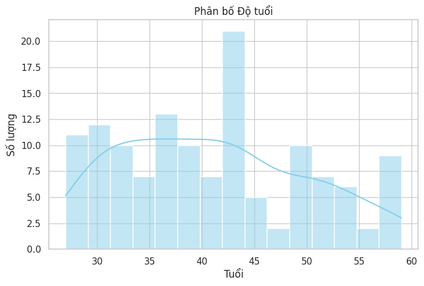

```python
# Biểu đồ biểu diễn Độ tuổi.
plt.figure(figsize=(8, 5))
sns.histplot(df['Age'], bins=15, kde=True, color='skyblue')
plt.title('Phân bố Độ tuổi')
plt.xlabel('Tuổi')
plt.ylabel('Số lượng')
plt.show()
```

Phân bố Độ tuổi (Age)

- Nhận xét: Dữ liệu bao quát đối tượng từ 27 đến 59 tuổi. Nhóm trung niên (từ 40-45 tuổi) chiếm tỷ lệ cao nhất trong khảo sát.

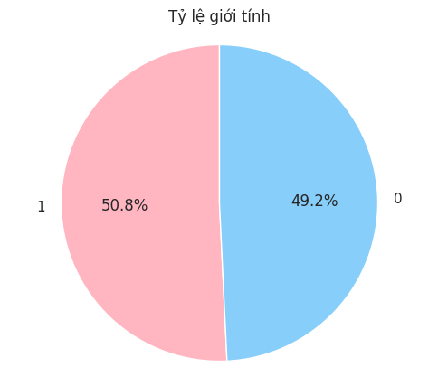

```python
# Biểu đồ biểu diễn Tỷ lệ giới tính.
colors = ['#FFB6C1', '#87CEFA']

plt.figure(figsize=(6, 5))
plt.pie(
    gender_counts,
    labels=gender_counts.index,
    autopct='%1.1f%%',
    colors=colors,
    startangle=90
)
plt.title('Tỷ lệ giới tính')
plt.axis('equal')
plt.show()
```

Tỷ lệ Giới tính (Gender)

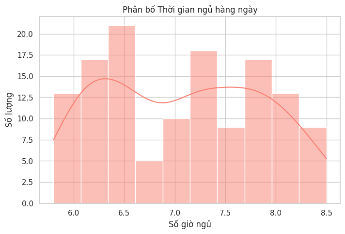

```python
# Biểu đồ biểu diễn Thời gian phân bố giấc ngủ.
plt.figure(figsize=(8, 5))
sns.histplot(df['Sleep Duration'], bins=10, kde=True, color='salmon')
plt.title('Phân bố Thời gian ngủ hàng ngày')
plt.xlabel('Số giờ ngủ')
plt.ylabel('Số lượng')
plt.show()
```

Thời gian ngủ hàng ngày (Sleep Duration)

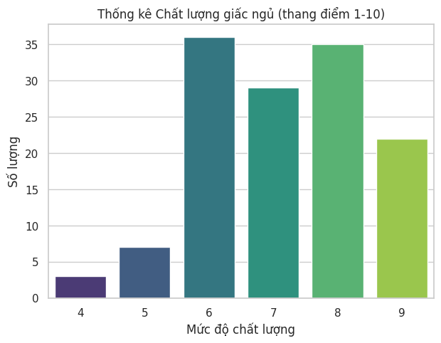

```python
# Biểu đồ biểu diễn Chất lượng giấc ngủ.
plt.figure(figsize=(7, 5))
sns.countplot(data=df, x='Quality of Sleep', palette='viridis')
plt.title('Thống kê Chất lượng giấc ngủ (thang điểm 1-10)')
plt.xlabel('Mức độ chất lượng')
plt.ylabel('Số lượng')
plt.show()
```

Chất lượng giấc ngủ (Quality of Sleep)

- Nhận xét: Phần lớn mọi người đánh giá giấc ngủ ở mức khá và tốt (điểm 6, 7, 8). Rất ít người cảm thấy chất lượng giấc ngủ ở mức tệ (dưới 5).

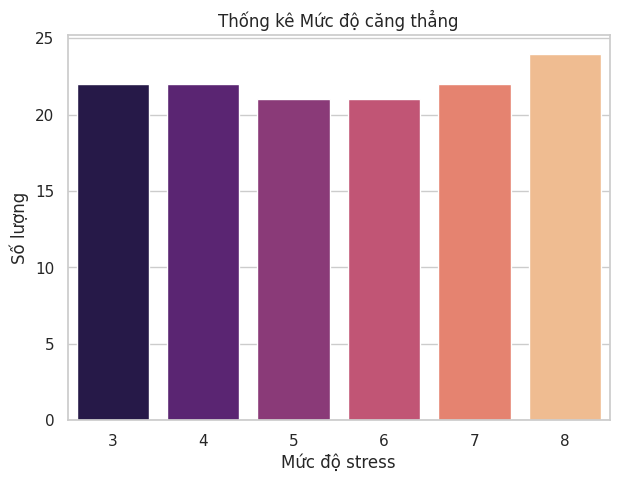

```python
# Biểu đồ biểu diễn Mức độ căng thẳng.
plt.figure(figsize=(7, 5))
sns.countplot(data=df, x='Stress Level', palette='magma')
plt.title('Thống kê Mức độ căng thẳng')
plt.xlabel('Mức độ stress')
plt.ylabel('Số lượng')
plt.show()
```

Mức độ căng thẳng (Stress Level)

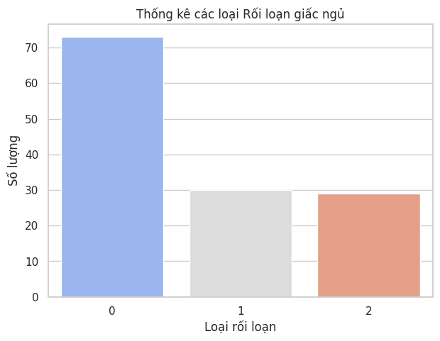

```python
# Biểu đồ biểu diễn Tình trạng Rối loạn giấc ngủ.
plt.figure(figsize=(7, 5))
temp_df = df.copy()
temp_df['Sleep Disorder'] = temp_df['Sleep Disorder'].fillna('None')
sns.countplot(data=temp_df, x='Sleep Disorder', palette='coolwarm')
plt.title('Thống kê các loại Rối loạn giấc ngủ')
plt.xlabel('Loại rối loạn')
plt.ylabel('Số lượng')
plt.show()
```

Tình trạng Rối loạn giấc ngủ (Sleep Disorder)

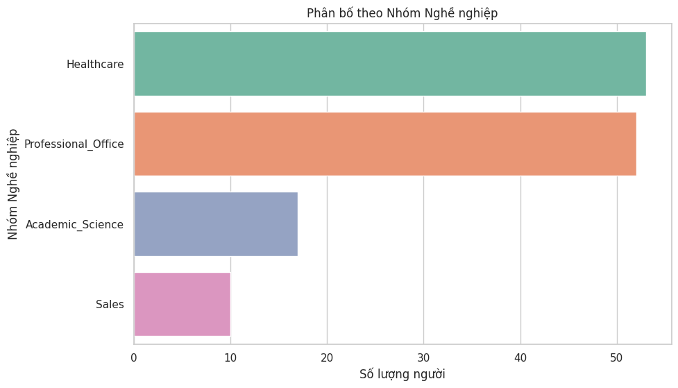

```python
# Biểu đồ biểu diễn Phân bố Nhóm Nghề nghiệp.
plt.figure(figsize=(10, 6))
sns.countplot(data=df, y='Occupation_Group', order=df['Occupation_Group'].value_counts().index, palette='Set2')
plt.title('Phân bố theo Nhóm Nghề nghiệp')
plt.xlabel('Số lượng người')
plt.ylabel('Nhóm Nghề nghiệp')
plt.show()
```

- Nhận xét:
  - Đặc điểm nghề nghiệp: Mẫu dữ liệu tập trung chủ yếu vào các nhóm ngành chuyên gia và dịch vụ cường độ cao như Y tá (Nurse), Bác sĩ (Doctor), Kỹ sư (Engineer) và Luật sư (Lawyer).
  - Sự phân hóa: Nhóm Y tá và Bác sĩ chiếm tỷ trọng lớn nhất, đây là những ngành nghề thường xuyên đối mặt với áp lực công việc cao và thời gian làm việc không cố định, điều này sẽ là cơ sở quan trọng để phân tích sự ảnh hưởng đến chất lượng giấc ngủ ở các phần sau.

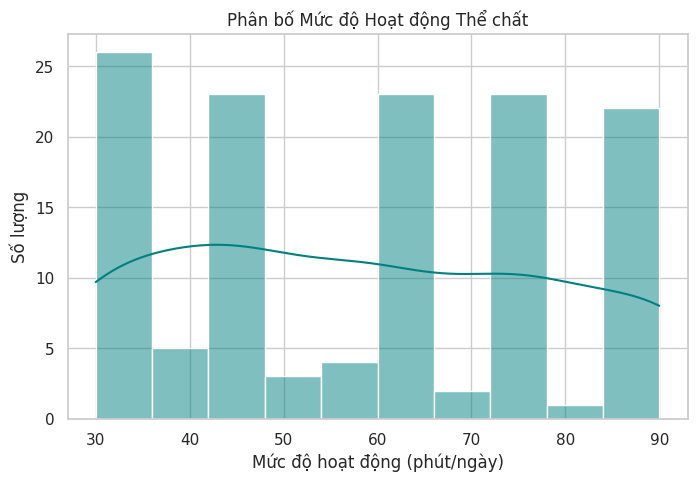

```python
# Biểu đồ biểu diễn Phân bố Mức độ Hoạt động Thể chất
plt.figure(figsize=(8, 5))
sns.histplot(df['Physical Activity Level'], bins=10, kde=True, color='teal')
plt.title('Phân bố Mức độ Hoạt động Thể chất')
plt.xlabel('Mức độ hoạt động (phút/ngày)')
plt.ylabel('Số lượng')
plt.show()
```

Mức độ hoạt động thể chất (Physical Activity Level)

- Nhận xét: Mức độ vận động trung bình khoảng 60 phút/ngày. Đây là một tập mẫu có lối sống khá năng động, không bị thụ động quá mức.

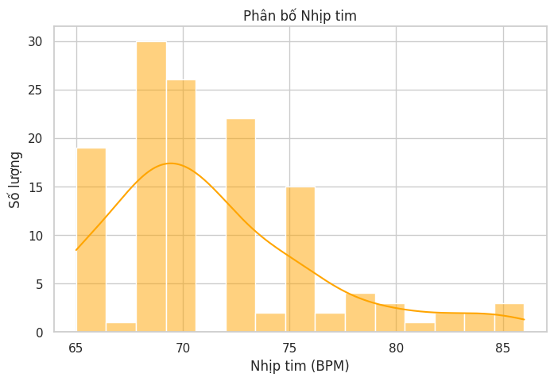

```python
# Biểu đồ phân bố Nhịp tim
plt.figure(figsize=(8, 5))
sns.histplot(df['Heart Rate'], bins=15, kde=True, color='orange')
plt.title('Phân bố Nhịp tim')
plt.xlabel('Nhịp tim (BPM)')
plt.ylabel('Số lượng')
plt.show()
```

Nhịp tim (Heart Rate)

- Nhận xét: Nhịp tim trung bình là 70 BPM, nằm trong ngưỡng khỏe mạnh bình thường (60-100 BPM).

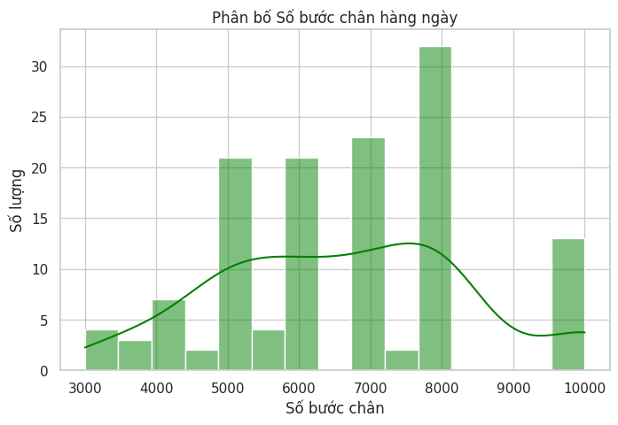

```python
# Biểu đồ phân bố Số bước chân hàng ngày
plt.figure(figsize=(8, 5))
sns.histplot(df['Daily Steps'], bins=15, kde=True, color='green')
plt.title('Phân bố Số bước chân hàng ngày')
plt.xlabel('Số bước chân')
plt.ylabel('Số lượng')
plt.show()
```

Số bước chân hàng ngày (Daily Steps)

- Nhận xét: Trung bình đạt gần 7,000 bước/ngày. Phần lớn mọi người duy trì mức vận động từ 5,000 đến 8,000 bước, phản ánh thói quen đi bộ tốt.

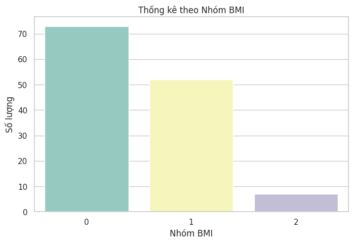

```python
# Biểu đồ thống kê Nhóm chỉ số BMI
plt.figure(figsize=(8, 5))
sns.countplot(data=df, x='BMI Category', palette='Set3', order=df['BMI Category'].value_counts().index)
plt.title('Thống kê theo Nhóm BMI')
plt.xlabel('Nhóm BMI')
plt.ylabel('Số lượng')
plt.show()
```

Nhóm chỉ số BMI (BMI Category)

- Nhận xét: Nhóm "Bình thường" (Normal) chiếm đa số, nhưng nhóm "Thừa cân" (Overweight) cũng chiếm tỷ trọng lớn (gần 40%), cho thấy nguy cơ tiềm ẩn về sức khỏe chuyển hóa.

#### Huyết áp (Blood Pressure)

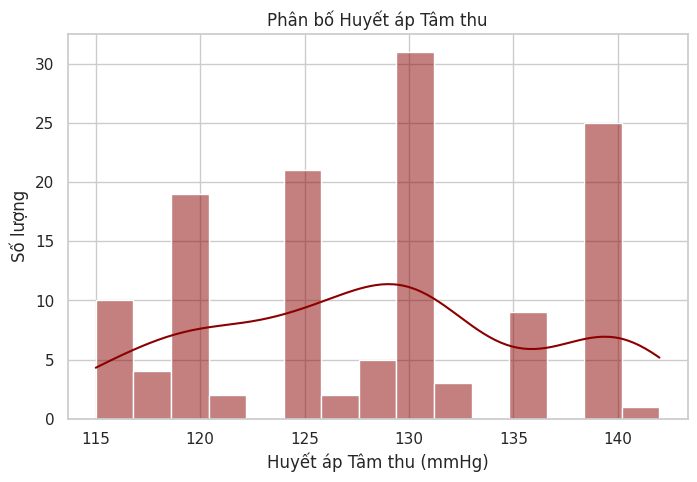

```python
# Vẽ biểu đồ Huyết áp Tâm thu
plt.figure(figsize=(8, 5))
sns.histplot(df['Systolic BP'], bins=15, kde=True, color='darkred')
plt.title('Phân bố Huyết áp Tâm thu')
plt.xlabel('Huyết áp Tâm thu (mmHg)')
plt.ylabel('Số lượng')
plt.show()
```

- Tâm thu (Systolic): Trung bình khoảng 128 mmHg, có xu hướng tiến sát ngưỡng tiền cao huyết áp (>130 mmHg).

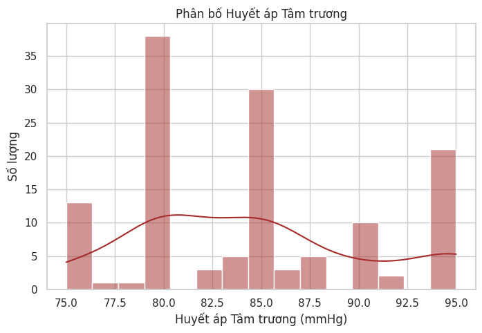

```python
# Vẽ biểu đồ Huyết áp Tâm trương
plt.figure(figsize=(8, 5))
sns.histplot(df['Diastolic BP'], bins=15, kde=True, color='brown')
plt.title('Phân bố Huyết áp Tâm trương')
plt.xlabel('Huyết áp Tâm trương (mmHg)')
plt.ylabel('Số lượng')
plt.show()
```

- Tâm trương (Diastolic): Trung bình khoảng 84 mmHg, đa số tập trung ở ngưỡng an toàn nhưng bắt đầu có dấu hiệu tăng ở một số nhóm đối tượng.

HEAT MAP

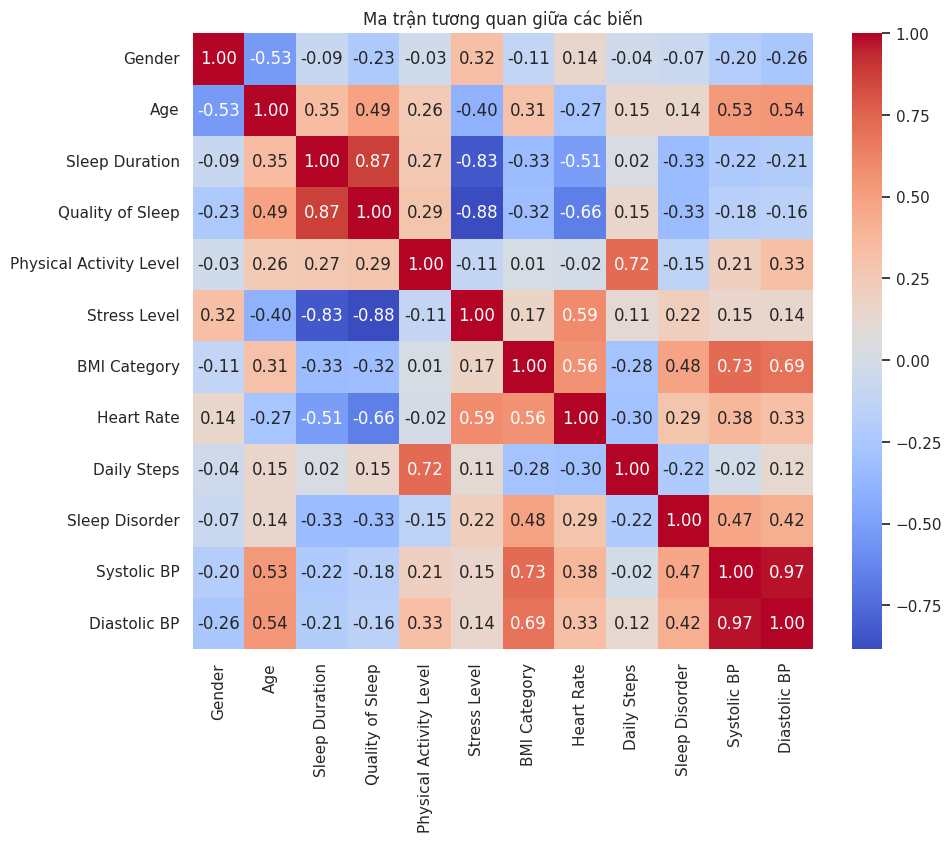

```python
plt.figure(figsize=(10, 8))
numeric_df = df.select_dtypes(include=['float64', 'int64'])
corr_matrix = numeric_df.corr()
sns.heatmap(corr_matrix, annot=True, cmap='coolwarm', fmt=".2f")
plt.title('Ma trận tương quan giữa các biến')
plt.show()
```

```python
# Mã hóa Occupation_Group
occupation_map = {'Healthcare': 0, 'Professional_Office': 1, 'Academic_Science': 2, 'Sales': 3}
df['Occupation_Group'] = df['Occupation_Group'].map(occupation_map)
df['Occupation_Group'].value_counts()
```

| Occupation_Group | count |
| --- | --- |
| 0 | 53 |
| 1 | 52 |
| 2 | 17 |
| 3 | 10 |

**dtype:** int64

Vì Occupation_Group đang là kiểu chuổi nên cần chuyển sang dạng số nguyên để có thể thực hiện việc tính ma trận heat map

Sau khi chuyển:

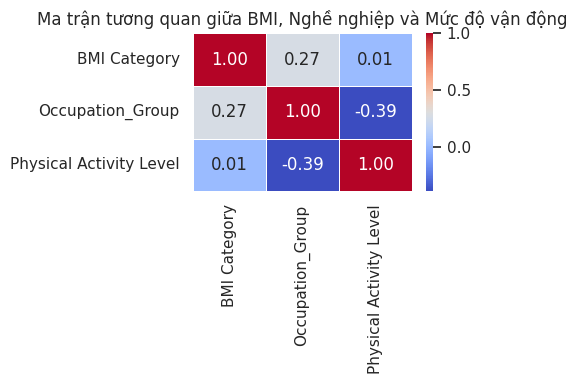

```python
# Ma Trận tương quan Đa Biến

vars_3 = ['BMI Category', 'Occupation_Group', 'Physical Activity Level']

corr_3 = df[vars_3].corr()

plt.figure(figsize=(5,4))
sns.heatmap(
    corr_3,
    annot=True,
    cmap='coolwarm',
    fmt=".2f",
    linewidths=0.5
)
plt.title('Ma trận tương quan giữa BMI, Nghề nghiệp và Mức độ vận động')
plt.tight_layout()
plt.show()
```

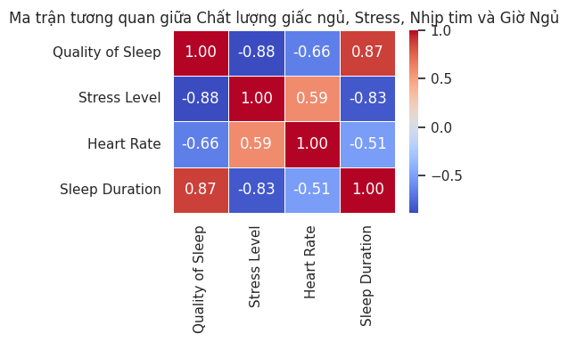

```python
# Ma Trận tương quan Đa Biến
vars_3 = ['Quality of Sleep', 'Stress Level', 'Heart Rate','Sleep Duration']

corr_3 = df[vars_3].corr()

plt.figure(figsize=(5,4))
sns.heatmap(
    corr_3,
    annot=True,
    cmap='coolwarm',
    fmt=".2f",
    linewidths=0.5
)
plt.title('Ma trận tương quan giữa Chất lượng giấc ngủ, Stress, Nhịp tim và Giờ Ngủ')
plt.tight_layout()
plt.show()
```

#### Phân tích Biến Mục Tiêu (Target Variable)

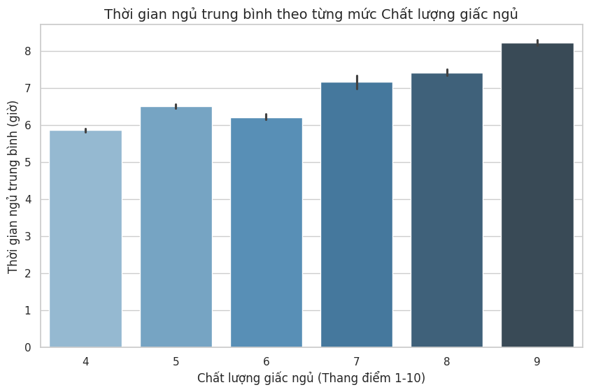

```python
# Thiết lập phong cách cho biểu đồ
sns.set(style="whitegrid")

# Vẽ biểu đồ cột: Chất lượng giấc ngủ vs Thời gian ngủ trung bình
plt.figure(figsize=(10, 6))

# sns.barplot mặc định sẽ tính toán giá trị trung bình (mean) cho biến y
sns.barplot(data=df, x='Quality of Sleep', y='Sleep Duration', palette='Blues_d')

plt.title('Thời gian ngủ trung bình theo từng mức Chất lượng giấc ngủ', fontsize=14)
plt.xlabel('Chất lượng giấc ngủ (Thang điểm 1-10)', fontsize=12)
plt.ylabel('Thời gian ngủ trung bình (giờ)', fontsize=12)

plt.show()
```

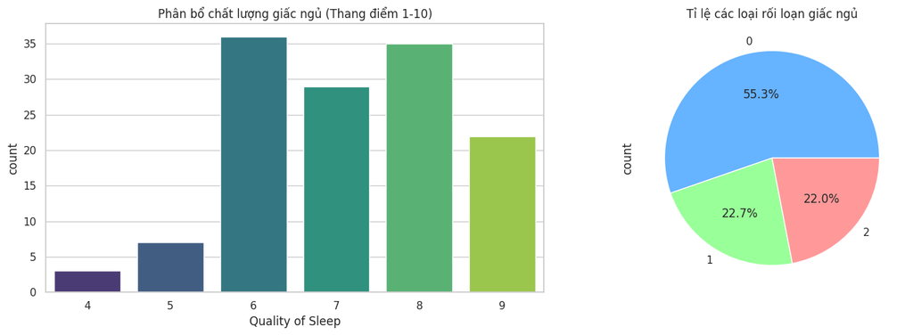

```python
sns.set(style="whitegrid")
plt.figure(figsize=(15, 5))

# Biểu đồ 1: Phân bổ chất lượng giấc ngủ
plt.subplot(1, 2, 1)
sns.countplot(data=df, x='Quality of Sleep', palette='viridis')
plt.title('Phân bổ chất lượng giấc ngủ (Thang điểm 1-10)')

# Biểu đồ 2: Tỉ lệ các loại rối loạn giấc ngủ
plt.subplot(1, 2, 2)
df['Sleep Disorder'].value_counts().plot.pie(autopct='%1.1f%%', colors=['#66b3ff','#99ff99','#ff9999'])
plt.title('Tỉ lệ các loại rối loạn giấc ngủ')

plt.tight_layout()
plt.show()
```

Phân tích:

- Nhóm None (Bình thường) chiếm đa số với 55.3%, điều này cho thấy bộ dữ liệu có sự mất cân bằng nhẹ giữa nhóm khỏe mạnh và nhóm bệnh lý.
- Hai nhóm bệnh lý là Sleep Apnea (Ngưng thở khi ngủ) và Insomnia (Mất ngủ) có tỉ lệ gần bằng nhau (khoảng 22% mỗi nhóm).

#### Mối quan hệ giữa Stress, Giấc ngủ và Sức khỏe

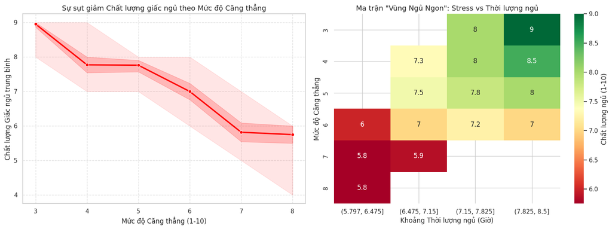

```python
plt.figure(figsize=(16, 6))

# Biểu đồ 1: Đường xu hướng chất lượng giấc ngủ theo mức độ căng thẳng
plt.subplot(1, 2, 1)
sns.lineplot(data=df, x='Stress Level', y='Quality of Sleep', marker='o', color='red', linewidth=2.5)
plt.fill_between(df.sort_values('Stress Level')['Stress Level'].unique(),
                 df.groupby('Stress Level')['Quality of Sleep'].min(),
                 df.groupby('Stress Level')['Quality of Sleep'].max(), color='red', alpha=0.1)
plt.title('Sự sụt giảm Chất lượng giấc ngủ theo Mức độ Căng thẳng', fontsize=13)
plt.xlabel('Mức độ Căng thẳng (1-10)')
plt.ylabel('Chất lượng Giấc ngủ trung bình')
plt.grid(True, linestyle='--', alpha=0.6)

# Biểu đồ 2: Heatmap thể hiện "Vùng chất lượng"
# Gom nhóm để tính chất lượng giấc ngủ trung bình cho mỗi cặp Stress-Thời lượng ngủ
pivot_table = df.pivot_table(index='Stress Level',
                             columns=pd.cut(df['Sleep Duration'], bins=4),
                             values='Quality of Sleep',
                             aggfunc='mean')

plt.subplot(1, 2, 2)
sns.heatmap(pivot_table, annot=True, cmap='RdYlGn', cbar_kws={'label': 'Chất lượng ngủ (1-10)'})
plt.title('Ma trận "Vùng Ngủ Ngon": Stress vs Thời lượng ngủ', fontsize=13)
plt.xlabel('Khoảng Thời lượng ngủ (Giờ)')
plt.ylabel('Mức độ Căng thẳng')

plt.tight_layout()
plt.show()
```

Phân tích kết quả:

==> Kết luận: Để cải thiện giấc ngủ, việc giảm áp lực tâm lý (Stress) hiệu quả hơn là chỉ cố gắng ngủ nhiều hơn về mặt thời gian.

#### Nghề nghiệp và Rủi ro sức khỏe

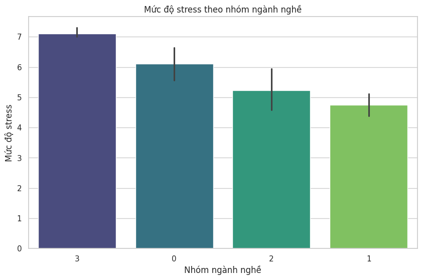

```python
plt.figure(figsize=(10, 6))
order = df.groupby('Occupation_Group')['Stress Level'].mean().sort_values(ascending=False).index
sns.barplot(x='Occupation_Group', y='Stress Level', data=df, order=order, palette='viridis')
plt.title('Mức độ stress theo nhóm ngành nghề')
plt.xlabel('Nhóm ngành nghề')
plt.ylabel('Mức độ stress')
plt.show()
```

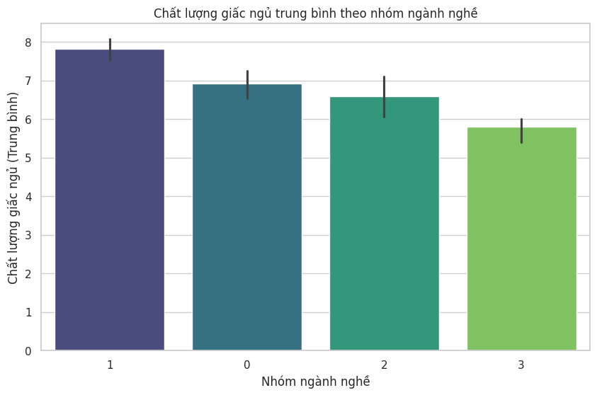

```python
plt.figure(figsize=(10, 6))
order = df.groupby('Occupation_Group')['Quality of Sleep'].mean().sort_values(ascending=False).index
sns.barplot(x='Occupation_Group', y='Quality of Sleep', data=df, order=order, palette='viridis')
plt.title('Chất lượng giấc ngủ trung bình theo nhóm ngành nghề')
plt.xlabel('Nhóm ngành nghề')
plt.ylabel('Chất lượng giấc ngủ (Trung bình)')
plt.show()
```

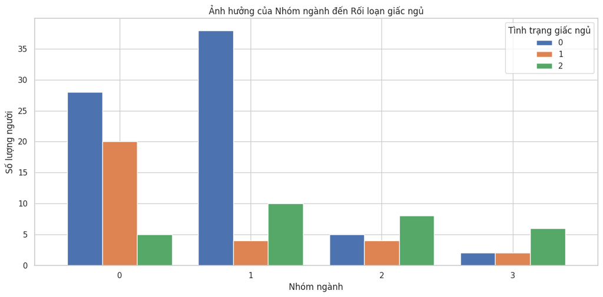

```python
plot_data = df.groupby(['Occupation_Group', 'Sleep Disorder']).size().unstack(fill_value=0)

ax = plot_data.plot(kind='bar', figsize=(12, 6), width=0.8)

plt.title('Ảnh hưởng của Nhóm ngành đến Rối loạn giấc ngủ')
plt.xlabel('Nhóm ngành')
plt.ylabel('Số lượng người')

plt.xticks(rotation=0)

plt.legend(title='Tình trạng giấc ngủ')
plt.tight_layout()
plt.show()
```

#### Tuổi, Giới và Rối loạn giấc ngủ

Gom biến Tuổi thành 3 nhóm:

- Young: 0-35 tuổi
- Middle_Age: 35-50 tuổi
- Senior: 50-100 tuổi

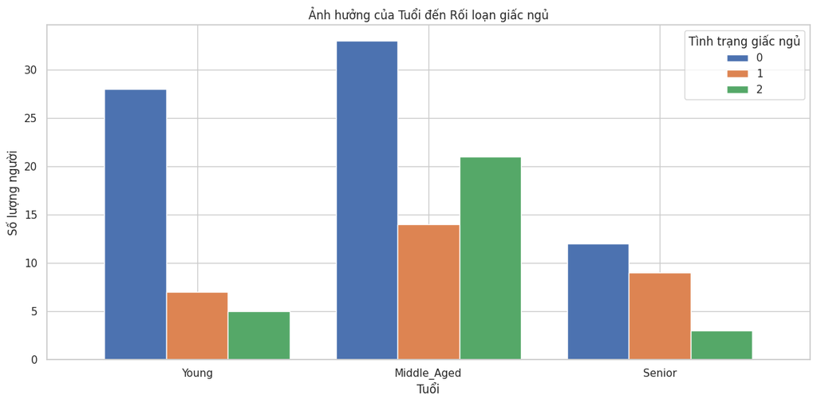

```python
df['Age_Group']=pd.cut(df['Age'], bins=[0, 35, 50, 100], labels=['Young', 'Middle_Aged', 'Senior'])
plot_data = df.groupby(['Age_Group', 'Sleep Disorder']).size().unstack(fill_value=0)

ax = plot_data.plot(kind='bar', figsize=(12, 6), width=0.8)

plt.title('Ảnh hưởng của Tuổi đến Rối loạn giấc ngủ')
plt.xlabel('Tuổi')
plt.ylabel('Số lượng người')

plt.xticks(rotation=0)

plt.legend(title='Tình trạng giấc ngủ')
plt.tight_layout()
plt.show()
```

Nhận xét:

- Trung niên: Bị rối loạn nặng nhất, đặc biệt là tình trạng mất ngủ cao vượt trội.
- Người trẻ: Có sức khỏe giấc ngủ tốt nhất, đa số không bị rối loạn.
- Người già: Tổng số ca khảo sát thấp nhưng ngưng thở khi ngủ chiếm tỷ lệ cao.

```
Các nhãn hiện có: [0 1 2]
```

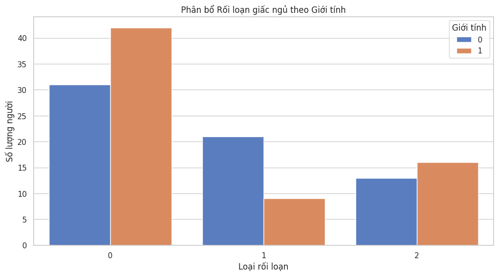

```python
# Kiểm tra nhãn thực tế đang có trong máy
print("Các nhãn hiện có:", df['Sleep Disorder'].unique())

# Vẽ biểu đồ so sánh Nam/Nữ cho TẤT CẢ các loại rối loạn
# Cách này chắc chắn sẽ ra hình vì nó không bắt buộc phải tìm đúng chữ 'Sleep Apnea'
plt.figure(figsize=(12, 6))
sns.countplot(data=df, x='Sleep Disorder', hue='Gender', palette='muted')

plt.title('Phân bổ Rối loạn giấc ngủ theo Giới tính')
plt.xlabel('Loại rối loạn')
plt.ylabel('Số lượng người')
plt.legend(title='Giới tính')
plt.show()
```

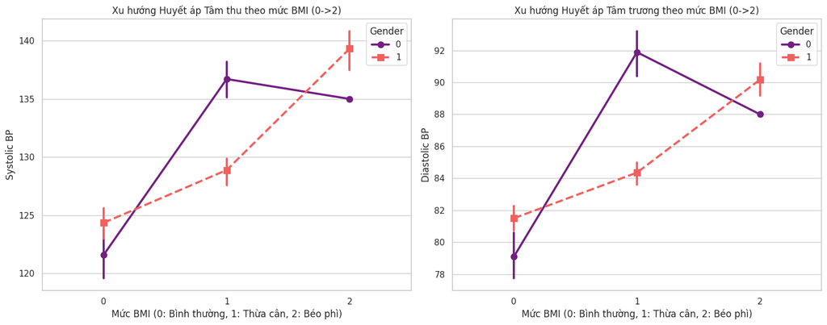

```python
fig, axes = plt.subplots(1, 2, figsize=(15, 6))

# Biểu đồ 1: Xu hướng Huyết áp Tâm thu
sns.pointplot(ax=axes[0], data=df, x='BMI Category', y='Systolic BP', hue='Gender', palette='magma', markers=['o', 's'], linestyles=['-', '--'])
axes[0].set_title('Xu hướng Huyết áp Tâm thu theo mức BMI (0->2)')
axes[0].set_xlabel('Mức BMI (0: Bình thường, 1: Thừa cân, 2: Béo phì)')

# Biểu đồ 2: Xu hướng Huyết áp Tâm trương
sns.pointplot(ax=axes[1], data=df, x='BMI Category', y='Diastolic BP', hue='Gender', palette='magma', markers=['o', 's'], linestyles=['-', '--'])
axes[1].set_title('Xu hướng Huyết áp Tâm trương theo mức BMI (0->2)')
axes[1].set_xlabel('Mức BMI (0: Bình thường, 1: Thừa cân, 2: Béo phì)')

plt.tight_layout()
plt.show()
```

## **Mô hình**

### Phân cụm K-Means

```python
from sklearn.preprocessing import StandardScaler
from sklearn.cluster import KMeans
from sklearn.metrics import silhouette_score

# 1. Lựa chọn các cột số để phân cụm
features = ['Age', 'Sleep Duration', 'Quality of Sleep', 'Physical Activity Level',
            'Stress Level', 'Heart Rate', 'Daily Steps', 'Systolic BP', 'Diastolic BP']
X = df[features]

# 2. Chuẩn hóa dữ liệu (Mean=0, Std=1)
scaler = StandardScaler()
X_scaled = scaler.fit_transform(X)
```

Chuẩn hóa: Sử dụng StandardScaler để đưa dữ liệu về $mean=0$ và $std=1$. Nếu không chuẩn hóa, biến Daily Steps (hàng nghìn) sẽ lấn át hoàn toàn Stress Level (1-10)

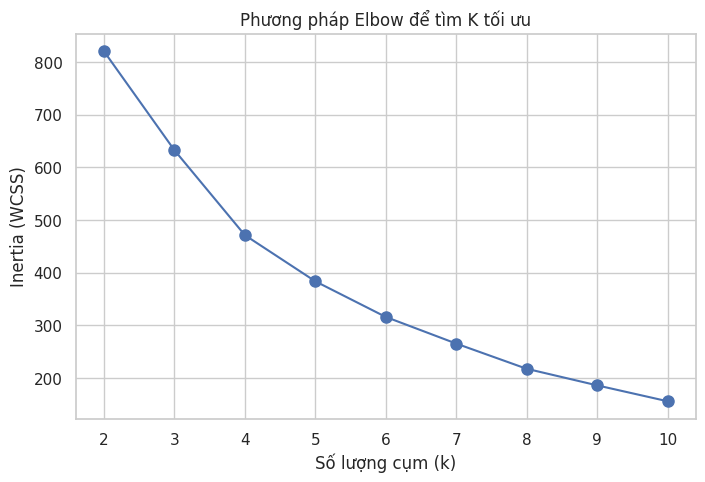

```python
import matplotlib.pyplot as plt

inertia = []
k_range = range(2, 11)

for k in k_range:
    kmeans = KMeans(n_clusters=k, random_state=42, n_init=10)
    kmeans.fit(X_scaled)
    inertia.append(kmeans.inertia_)

# Vẽ biểu đồ Elbow với điểm hình tròn
plt.figure(figsize=(8, 5))
plt.plot(k_range, inertia, 'bo-', markersize=8) # 'bo-' tạo điểm hình tròn màu xanh
plt.xlabel('Số lượng cụm (k)')
plt.ylabel('Inertia (WCSS)')
plt.title('Phương pháp Elbow để tìm K tối ưu')
plt.grid(True)
plt.show()
```

```python
score = silhouette_score(X_scaled, kmeans.labels_)
print(f"Chỉ số Silhouette cho k=3: {score:.3f}")
```

[output not shown]

```python
# Khởi tạo và chạy K-Means với k=3
kmeans = KMeans(n_clusters=3, random_state=42, n_init=10)
df['Cluster'] = kmeans.fit_predict(X_scaled)

# Hiển thị đặc trưng trung bình của từng cụm để rút ra tri thức
cluster_analysis = df.groupby('Cluster')[features].mean()
print(cluster_analysis)
```

```
               Age  Sleep Duration  Quality of Sleep  Physical Activity Level  \
Cluster
0        36.333333        6.388095          5.880952                40.619048
1        39.500000        7.621667          7.933333                63.533333
2        51.100000        6.976667          7.366667                73.000000

         Stress Level  Heart Rate  Daily Steps  Systolic BP  Diastolic BP
Cluster
0            7.023810   75.238095  5276.190476   129.071429     84.285714
1            4.650000   68.433333  7123.333333   122.616667     80.183333
2            5.233333   71.100000  7573.333333   138.866667     93.600000
```

[output not shown]

- Cụm 0 - Nhóm Nguy cơ Stress (Stress-Prone Group): Nhóm người trẻ tuổi nhất (36 tuổi), có mức Stress cao nhất (7.02) và chất lượng giấc ngủ thấp nhất. Đây là nhóm cần ưu tiên các giải pháp giảm căng thẳng tâm lý.
- Cụm 1 - Nhóm Cân bằng (Healthy/Balanced Group): Có thời gian ngủ dài nhất (7.62h), chất lượng ngủ tốt nhất và mức độ Stress thấp nhất. Đây là nhóm hình mẫu về lối sống lành mạnh.
- Cụm 2 - Nhóm Nguy cơ bệnh lý (At-Risk/Seniors): Nhóm lớn tuổi nhất (51 tuổi), có chỉ số Huyết áp cao nhất (138.87/93.6) và vận động nhiều (7573 bước). Nhóm này có nguy cơ cao mắc các bệnh về tim mạch.

**Nhận xét**  
Ở Cụm 2, dù số bước chân cao nhất (~7573 bước) nhưng huyết áp vẫn ở mức nguy hiểm. Điều này cho thấy với người trên 50 tuổi, chỉ vận động thôi là chưa đủ, cần kiểm soát cả chế độ ăn uống và áp lực tim mạch.

Cụm 0 có Stress cao nhất nhưng huyết áp chưa cao bằng Cụm 2. Tri thức rút ra là: Stress ảnh hưởng đến chất lượng ngủ ngay lập tức (nhóm trẻ), nhưng huyết áp cao là hệ quả tích tụ theo độ tuổi (nhóm già).

### Phân loại

```python
from sklearn.model_selection import train_test_split
from sklearn.preprocessing import StandardScaler
from sklearn.ensemble import RandomForestClassifier
from sklearn.linear_model import LogisticRegression
from sklearn.neighbors import KNeighborsClassifier
from sklearn.tree import DecisionTreeClassifier
from sklearn.metrics import accuracy_score, classification_report, confusion_matrix

# 1. Lựa chọn tập đặc trưng (Features) và nhãn (Target)
# X bao gồm các chỉ số tim mạch "chuông báo động" và lối sống
features = ['Age', 'Sleep Duration', 'Quality of Sleep', 'Physical Activity Level',
            'Stress Level', 'Heart Rate', 'Daily Steps', 'Systolic BP', 'Diastolic BP']
# Thêm các biến định tính đã được mã hóa thành dummy variables
X = pd.get_dummies(df[features + ['Occupation_Group', 'BMI Category']], drop_first=True)
y = df['Sleep Disorder']

# 2. Chia tập dữ liệu 80/20
X_train, X_test, y_train, y_test = train_test_split(X, y, test_size=0.2, random_state=42)

# 3. Chuẩn hóa dữ liệu (Z-score Scaling) để các mô hình khoảng cách như KNN hoạt động tốt
scaler = StandardScaler()
X_train_scaled = scaler.fit_transform(X_train)
X_test_scaled = scaler.transform(X_test)
```

```python
# Khởi tạo và huấn luyện
rf_model = RandomForestClassifier(n_estimators=100, random_state=42)
rf_model.fit(X_train, y_train)

# Dự đoán trên tập kiểm tra
y_pred = rf_model.predict(X_test)
```

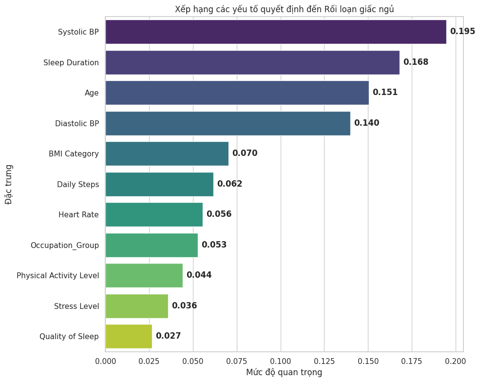

```python
import pandas as pd
import numpy as np
import seaborn as sns
import matplotlib.pyplot as plt

# 1. Đảm bảo lấy đúng độ quan trọng từ mô hình
importances = rf_model.feature_importances_

# 2. Lấy danh sách cột từ đúng biến X đã dùng để model.fit()
# Nếu bạn dùng X_train để huấn luyện, hãy lấy X_train.columns
feature_names = X_train.columns

# 3. Sắp xếp theo thứ tự giảm dần
indices = np.argsort(importances)[::-1]

# 4. Vẽ biểu đồ với dữ liệu đã khớp
plt.figure(figsize=(10, 8))
sns.set_theme(style="whitegrid")

sns.barplot(
    x=importances[indices],
    y=feature_names[indices],
    hue=feature_names[indices],
    palette="viridis",
    legend=False
)

# Thêm nhãn giá trị
for i, v in enumerate(importances[indices]):
    plt.text(v + 0.002, i, f'{v:.3f}', va='center', fontweight='bold')

plt.title("Xếp hạng các yếu tố quyết định đến Rối loạn giấc ngủ")
plt.xlabel("Mức độ quan trọng")
plt.ylabel("Đặc trưng")
plt.tight_layout()
plt.show()
```

- Systolic BP (Huyết áp tâm thu - 0.195): Đây là yếu tố quan trọng nhất. Nó khẳng định giả thuyết rằng áp lực mạch máu cao là dấu hiệu nhận diện hàng đầu cho các rối loạn giấc ngủ nghiêm trọng.
- Age (Tuổi - 0.151) & Sleep Duration (Thời lượng ngủ - 0.168): Hai yếu tố này xếp ngay sau với trọng số tương đương. Điều này cho thấy tuổi tác ảnh hưởng trực tiếp đến cấu trúc giấc ngủ; người càng lớn tuổi thì thời lượng ngủ thường thay đổi, dẫn đến nguy cơ rối loạn cao hơn.
- Diastolic BP (Huyết áp tâm trương - 0.140): Củng cố thêm vai trò của sức khỏe tim mạch trong việc dự báo bệnh lý.
- Các yếu tố lối sống (BMI, Stress, Steps): Có trọng số thấp hơn nhưng vẫn đóng vai trò điều phối. Đặc biệt, BMI Category và Stress Level là những biến quan trọng để phân biệt giữa "Mất ngủ" (thường do stress) và "Ngưng thở khi ngủ" (thường do thể trạng BMI).

### Luật kết hợp

```python
import warnings
warnings.filterwarnings('ignore')
```

```python
import pandas as pd
from mlxtend.frequent_patterns import apriori, association_rules
# Chuẩn bị dữ liệu cho quy luật
df_rules = df.copy()

# Chia Huyết áp tâm thu (Systolic BP) thành nhóm
df_rules['Systolic_Group'] = pd.cut(df['Systolic BP'], bins=[0, 120, 135, 200], labels=['Normal_BP', 'Elevated_BP', 'High_BP'])

# Chia Stress Level thành nhóm
df_rules['Stress_Group'] = pd.cut(df['Stress Level'], bins=[0, 4, 7, 10], labels=['Low_Stress', 'Mid_Stress', 'High_Stress'])

# Chia Tuổi thành nhóm
df_rules['Age_Group'] = pd.cut(df['Age'], bins=[0, 35, 50, 100], labels=['Young', 'Middle_Aged', 'Senior'])

columns_for_rules = ['Gender', 'Occupation_Group', 'BMI Category', 'Sleep Disorder',
                     'Systolic_Group', 'Stress_Group', 'Age_Group']

# Chuyển đổi sang One-Hot Encoding
df_onehot = pd.get_dummies(df_rules[columns_for_rules], columns=columns_for_rules)

frequent_itemsets = apriori(df_onehot, min_support=0.1, use_colnames=True)

rules = association_rules(frequent_itemsets, metric="lift", min_threshold=1.2)

sleep_rules = rules[rules['consequents'].astype(str).str.contains('Sleep Disorder_')]

display(sleep_rules[['antecedents', 'consequents', 'support', 'confidence', 'lift']].sort_values(by='confidence', ascending=False).head(10))
```

|  | antecedents | consequents | support | confidence | lift |
| --- | --- | --- | --- | --- | --- |
| 1261 | (Systolic_Group_Normal_BP, Stress_Group_Mid_St... | (Sleep Disorder_0) | 0.106061 | 0.933333 | 1.687671 |
| 1264 | (Systolic_Group_Normal_BP, Stress_Group_Mid_St... | (Sleep Disorder_0, BMI Category_0) | 0.106061 | 0.933333 | 2.124138 |
| 504 | (Systolic_Group_Normal_BP, Stress_Group_Mid_St... | (Sleep Disorder_0) | 0.106061 | 0.933333 | 1.687671 |
| 392 | (Stress_Group_Low_Stress, Occupation_Group_1) | (Sleep Disorder_0) | 0.143939 | 0.904762 | 1.636008 |
| 1139 | (Occupation_Group_1, Stress_Group_Low_Stress, ... | (Sleep Disorder_0) | 0.136364 | 0.900000 | 1.627397 |
| 1274 | (Systolic_Group_Normal_BP, BMI Category_0, Age... | (Sleep Disorder_0) | 0.128788 | 0.894737 | 1.617880 |
| 1278 | (Systolic_Group_Normal_BP, Age_Group_Young) | (Sleep Disorder_0, BMI Category_0) | 0.128788 | 0.894737 | 2.036298 |
| 859 | (Systolic_Group_Normal_BP, Gender_1) | (Sleep Disorder_0, BMI Category_0) | 0.128788 | 0.894737 | 2.036298 |
| 246 | (Systolic_Group_Normal_BP, Gender_1) | (Sleep Disorder_0) | 0.128788 | 0.894737 | 1.617880 |
| 509 | (Systolic_Group_Normal_BP, Age_Group_Young) | (Sleep Disorder_0) | 0.128788 | 0.894737 | 1.617880 |

Mối quan hệ giữa Huyết áp và Tâm lý:

- Quy luật: Nếu {Huyết áp bình thường (Normal_BP), Stress trung bình (Mid_Stress)} $\rightarrow$ {Không bị rối loạn giấc ngủ}.
- Chỉ số: Confidence: 0.933 (93.3%), Lift: 1.69.

Mối quan hệ giữa Nghề nghiệp và Thể trạng:

- Quy luật: Nếu {Nhóm nghề nghiệp Văn phòng (Professional_Office), Stress thấp, BMI bình thường (Category_0)} $\rightarrow$ {Không bị rối loạn giấc ngủ}.
- Chỉ số: Confidence: 0.90 (90%), Lift: 1.62.

Lí do chỉ ra nhóm "Không bị rối loạn" (Sleep Disorder_0):

- Vì nhóm "Không bị rối loạn" xuất hiện rất nhiều, các tập hợp đi kèm với nó dễ dàng vượt qua ngưỡng min_support=0.1
- Các nhóm "Mất ngủ" hay "Ngưng thở" có ít mẫu hơn, nên các quy luật liên quan đến chúng có thể không đủ tần suất để xuất hiện trong bảng kết quả.

Giải pháp:

- Hạ thấp min_support
- Thay đổi điều kiện lọc để chỉ hiện nhãn 1 hoặc 2

```python
frequent_itemsets = apriori(df_onehot, min_support=0.03, use_colnames=True)
rules = association_rules(frequent_itemsets, metric="lift", min_threshold=1.2)

# Lọc riêng cho nhãn 1 (Sleep Apnea) và 2 (Insomnia)
disorder_rules = rules[
    rules['consequents'].astype(str).str.contains('Sleep Disorder_1') |
    rules['consequents'].astype(str).str.contains('Sleep Disorder_2')
]
display(disorder_rules.sort_values(by='confidence', ascending=False).head(10))
```

|  | antecedents | consequents | antecedent support | consequent support | support | confidence | lift | representativity | leverage | conviction | zhangs_metric | jaccard | certainty | kulczynski |
| --- | --- | --- | --- | --- | --- | --- | --- | --- | --- | --- | --- | --- | --- | --- |
| 10983 | (Stress_Group_Low_Stress, Occupation_Group_2, ... | (Sleep Disorder_2, Age_Group_Middle_Aged) | 0.045455 | 0.159091 | 0.037879 | 0.833333 | 5.238095 | 1.0 | 0.030647 | 5.045455 | 0.847619 | 0.227273 | 0.801802 | 0.535714 |
| 10979 | (Age_Group_Middle_Aged, Stress_Group_Low_Stres... | (Sleep Disorder_2) | 0.045455 | 0.219697 | 0.037879 | 0.833333 | 3.793103 | 1.0 | 0.027893 | 4.681818 | 0.771429 | 0.166667 | 0.786408 | 0.502874 |
| 16034 | (Stress_Group_Low_Stress, Occupation_Group_2, ... | (Systolic_Group_Elevated_BP, Sleep Disorder_2) | 0.045455 | 0.181818 | 0.037879 | 0.833333 | 4.583333 | 1.0 | 0.029614 | 4.909091 | 0.819048 | 0.200000 | 0.796296 | 0.520833 |
| 15400 | (Systolic_Group_Elevated_BP, Stress_Group_Low_... | (Sleep Disorder_2, Age_Group_Middle_Aged) | 0.045455 | 0.159091 | 0.037879 | 0.833333 | 5.238095 | 1.0 | 0.030647 | 5.045455 | 0.847619 | 0.227273 | 0.801802 | 0.535714 |
| 16085 | (Stress_Group_Low_Stress, Occupation_Group_2, ... | (Systolic_Group_Elevated_BP, Age_Group_Middle_... | 0.045455 | 0.045455 | 0.037879 | 0.833333 | 18.333333 | 1.0 | 0.035813 | 5.727273 | 0.990476 | 0.714286 | 0.825397 | 0.833333 |
| 16086 | (Systolic_Group_Elevated_BP, Stress_Group_Low_... | (Gender_0, Age_Group_Middle_Aged, Sleep Disord... | 0.045455 | 0.053030 | 0.037879 | 0.833333 | 15.714286 | 1.0 | 0.035468 | 5.681818 | 0.980952 | 0.625000 | 0.824000 | 0.773810 |
| 16050 | (Systolic_Group_Elevated_BP, Stress_Group_Low_... | (Age_Group_Middle_Aged, Sleep Disorder_2, Gend... | 0.045455 | 0.060606 | 0.037879 | 0.833333 | 13.750000 | 1.0 | 0.035124 | 5.636364 | 0.971429 | 0.555556 | 0.822581 | 0.729167 |
| 16041 | (Stress_Group_Low_Stress, BMI Category_1, Syst... | (Sleep Disorder_2, Occupation_Group_2) | 0.045455 | 0.060606 | 0.037879 | 0.833333 | 13.750000 | 1.0 | 0.035124 | 5.636364 | 0.971429 | 0.555556 | 0.822581 | 0.729167 |
| 16052 | (Gender_0, Stress_Group_Low_Stress, Occupation... | (Systolic_Group_Elevated_BP, Sleep Disorder_2,... | 0.045455 | 0.136364 | 0.037879 | 0.833333 | 6.111111 | 1.0 | 0.031680 | 5.181818 | 0.876190 | 0.263158 | 0.807018 | 0.555556 |
| 16053 | (Age_Group_Middle_Aged, Stress_Group_Low_Stres... | (Systolic_Group_Elevated_BP, Sleep Disorder_2,... | 0.045455 | 0.083333 | 0.037879 | 0.833333 | 10.000000 | 1.0 | 0.034091 | 5.500000 | 0.942857 | 0.416667 | 0.818182 | 0.643939 |

Nhóm này tập trung vào các yếu tố nguy cơ gây ra chứng mất ngủ, đặc biệt là trong ngành Giáo dục - Nghiên cứu.  
Mối quan hệ giữa Nghề nghiệp và Độ tuổi (Luật mạnh nhất):

- Quy luật: Nếu {BMI thừa cân (Category_1), Nhóm Academic_Science, Stress thấp} $\rightarrow$ {Nữ giới, Tuổi trung niên, Huyết áp chớm cao (Elevated_BP), Mất ngủ (Insomnia)}.
- Chỉ số: Confidence: 0.833 (83.3%), Lift: 18.33.

Mối quan hệ giữa Nghề nghiệp và Huyết áp:

- Quy luật: Nếu {Nhóm Academic_Science, Stress thấp, Huyết áp chớm cao (Elevated_BP)} $\rightarrow$ {Nữ giới, Tuổi trung niên, BMI thừa cân, Mất ngủ}.
- Chỉ số: Confidence: 0.833, Lift: 15.71.

Mối quan hệ tổng hợp các yếu tố sinh học:

- Quy luật: Nếu {Tuổi trung niên, Nữ giới, Huyết áp chớm cao, Stress thấp, BMI thừa cân} $\rightarrow$ {Nhóm Academic_Science, Mất ngủ}.
- Chỉ số: Confidence: 0.833, Lift: 13.75.

**Nhận xét:**

- Sự đối lập giữa hai nhóm: Nhóm văn phòng gắn liền với trạng thái không bệnh lý khi duy trì huyết áp và BMI bình thường. Trong khi đó, nhóm giáo dục - nghiên cứu (Academic_Science) lại chịu rủi ro mất ngủ cực cao khi bước vào tuổi trung niên và có dấu hiệu huyết áp chớm cao.
- Tầm quan trọng của Huyết áp: Chỉ số huyết áp (Systolic_Group) là yếu tố xuất hiện xuyên suốt trong cả hai nhóm luật, đóng vai trò là "chuông báo động" sớm cho các rối loạn giấc ngủ.
- Yếu tố bất ngờ: Ở nhóm mất ngủ, dù Stress báo cáo ở mức thấp (Low_Stress), nhưng các yếu tố công việc và sinh học vẫn dẫn đến tỉ lệ bệnh lý rất cao (Lift > 10).

## **INSIGHT THEO CÂU HỎI NGHIÊN CỨU**

#### **1. Insight cho bài toán Phân loại (Classification)**

Câu hỏi:

- Yếu tố lối sống và sức khỏe nào là quan trọng nhất trong việc dự đoán một người có bị rối loạn giấc ngủ (Sleep Disorder) hay không?

#### **2. Insight cho bài toán Phân cụm (Clustering)**

Câu hỏi:

- Liệu có thể phân chia các cá nhân thành các nhóm (Persona) với đặc điểm lối sống và rủi ro sức khỏe khác nhau hay không, và đặc điểm của mỗi nhóm là gì?

**Insight chính**

- Phân tích phân cụm cho thấy có thể chia cá nhân thành các nhóm (persona) rõ rệt, mỗi nhóm đại diện cho một kiểu lối sống và mức độ rủi ro rối loạn giấc ngủ khác nhau.

**Các nhóm Persona tiêu biểu**

**↪Nhóm 1: Persona “Khỏe mạnh – Nguy cơ thấp”**

- Stress Level: Thấp
- Physical Activity Level: Cao
- BMI: Normal
- Sleep Duration & Quality: Ổn định
- Sleep Disorder: Hầu như không có

**Insight:** Đây là nhóm có lối sống lành mạnh, Stress được kiểm soát tốt nên nguy cơ rối loạn giấc ngủ gần như không đáng kể.

**↪Nhóm 2: Persona “Ngủ đủ nhưng Stress cao”**

- Stress Level: Trung bình – Cao
- Sleep Duration: Thấp hoặc Trung Bình
- Physical Activity Level: Trung bình
- Sleep Disorder: Chủ yếu là Insomnia

**Insight:** Ngủ đủ giờ không đảm bảo tránh được rối loạn giấc ngủ nếu Stress không được kiểm soát. Đây là nhóm dễ bị mất ngủ do áp lực tinh thần.

**↪Nhóm 3: Persona “Nguy cơ cao – Lối sống kém lành mạnh”**

- Stress Level: Cao
- Physical Activity Level: Thấp
- BMI: Overweight/Obese
- Sleep Duration: Thấp hoặc không ổn định
- Sleep Disorder: Tỷ lệ cao (đặc biệt Sleep Apnea)

**Insight:** Sự kết hợp giữa Stress cao, ít vận động và BMI cao tạo ra nguy cơ rối loạn giấc ngủ nghiêm trọng nhất.

**Insight tổng hợp (Clustering)**

✈ Các cá nhân không giống nhau về rủi ro giấc ngủ; rối loạn giấc ngủ hình thành từ tổ hợp lối sống ☹ Stress ⛹ thể trạng, chứ không phải từ một yếu tố đơn lẻ.